# Plotting metagenes with MetaPlotR

### Summary

MetaPlotR is a Perl/R pipeline for creating metagene plots. A metagene is a density plot or histogram of sites of interest (e.g. protein binding sites or RNA modifications) along a simplified transcript model containing a 5’UTR, coding sequence and 3’UTR.

### Requirements

1. Unix/Linux based operating system (tested with Debian 7.8 and OS X 10.10.5)
2. Perl (tested with version 5.22.2)
3. R (tested with version 3.2.2); “scales” and “ggplot2” packages
4. Bedtools (tested with version 2.22.1)

### Prepare primary data

#### Create query bed file

A six-column BED file (i.e. BED6) is required (see [here](https://genome.ucsc.edu/FAQ/FAQformat#format1) for specifications – Note: columns 4 and 5 can be arbitrary). This tutorial uses a BED file of N6-methyladenosine (m6A) sites generated from Linder *et al.* Nat. Methods, 2015 (m6a.sorted.bed) and one of pseudouridine sites (pseudoU) genrated from Schraga *et al.* Cell, 2014 (pseudoU.sorted.bed). The sample BED files are located in the Github repository along with the MetaPlotR scripts. This files were sorted using the Unix sort command:

`sort –k1,1 –k2,2n m6a.bed > m6a.sorted.bed`

`sort –k1,1 –k2,2n pseudoU.bed > pseudoU.sorted.bed`

NOTE: MetaPlotR expects a bed file with 0-based single nucleotide coordinates.

#### Download genome and annotation file

Download genome of interest from the UCSC genome browser download page (http://hgdownload.soe.ucsc.edu/downloads.html). Here we use the hg19 human genome located here (http://hgdownload.soe.ucsc.edu/goldenPath/hg19/bigZips/chromFa.tar.gz).

Next, download the extended gene prediction tables from the UCSC Table Browser (http://genome.ucsc.edu/cgi-bin/hgTables). The figure below shows the necessary drop-down options to download the gencode gene annotations for the hg19 human genome.

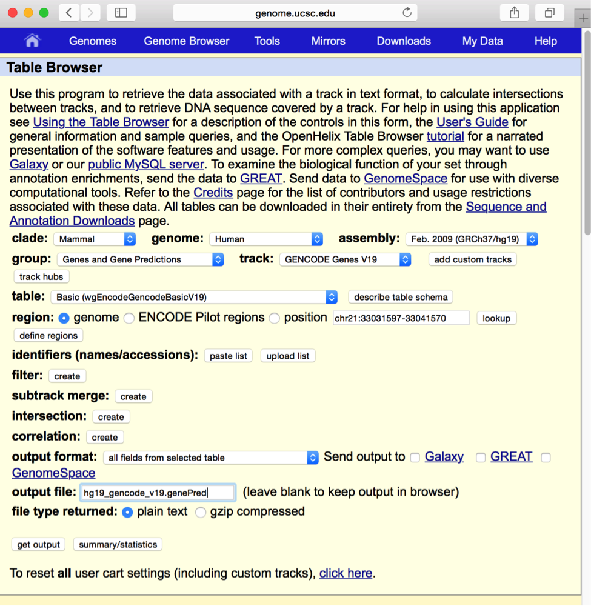

### Understanding the distance measure file

All proceeding code are in R (https://www.r-project.org/). We recommend working with R using RStudio (https://www.rstudio.com/).  
The input for this section is the metagene coordinates file outputted from **rel_and_abs_dist_calc.pl** (available on Github)

Read in distance measure file for m6A

```r
m6a.dist <- read.delim ("m6a.dist.measures.txt", header = T)
```

View the number of rows and columns in the dataset

```r
dim(m6a.dist)
```

```
## [1] 20903    14
```

View the first few lines

```r
head(m6a.dist)
```

```
##    chr  coord gene_name          refseqID rel_location utr5_st utr5_end
## 1 chr1 878151    SAMD11 ENST00000342066.3     1.624145    1359     1277
## 2 chr1 879955     NOC2L ENST00000327044.6     2.242857    2418     2369
## 3 chr1 934375      HES4 ENST00000304952.6     2.673684     867      730
## 4 chr1 934375      HES4 ENST00000428771.2     2.659794    1006      808
## 5 chr1 934375      HES4 ENST00000484667.2     2.719101     641      634
## 6 chr1 934423      HES4 ENST00000304952.6     2.168421     819      682
##   cds_st cds_end utr3_st utr3_end utr5_size cds_size utr3_size
## 1   1276    -769    -770    -1191        82     2045       421
## 2   2368     119     118     -371        49     2249       489
## 3    729      64      63      -31       137      665        94
## 4    807      64      63      -33       198      743        96
## 5    633      64      63      -25         7      569        88
## 6    681      16      15      -79       137      665        94
```

This input file contains 20903 rows and 14 columns. Each row represents a single site (in this example an m6A site). The column headers for the first four columns are self explanatory. The fifth column “rel_location” (for relative location) contains the calculated metagene coordinates. In its simplest form (i.e. non-normalized), the metagene coordinates from 0 to 1 represent the 5’UTR with 0 being closer to the beginning of the 5’UTR and 1 closer to the end. Similarly, 1 to 2 represents the CDS and 2 to 3 the 3’UTR. A histogram/density plot of the “rel_location” value gives the standard metagene.

In addition to the standard metagene which is based on the relative location of sites in transcripts, this next six columns (utr5_st, utr5_end, cds_st, cds_end, utr3_st, utr3_end) contain information for plotting the absolute distance of sites from several points of interest. For example, in this dataset the third row has a value of +63 under column header “utr3_st”. That means the site is 63 nucleotides upstream of the 3’UTR start site.

The last three columns contain the lengths of the 5’UTRs, coding sequences and 3’UTRs.

### Selecting gene isoforms for metagene analysis

The dataset is redundant – a given site is represented by multiple transcript isoforms. The choice of which isoforms to choose should be informed by the underlying biology. For example, if a gene expression dataset is available, one option may be to pick the highest expressed isoform. Another option is to pick the longest isoform, which is likely to capture more sites. Below is sample code for picking the largest isoforms

```r
trx_len <- m6a.dist$utr5_size + m6a.dist$cds_size + m6a.dist$utr3_size
m6a.dist <- m6a.dist[order(m6a.dist$gene_name, trx_len),] # sort by gene name, then transcript length
m6a.dist <- m6a.dist[duplicated(m6a.dist$gene_name),] # select the longest isoform
#m6a.dist <- m6a.dist[duplicated(m6a.dist$gene_name),] # select the shortest isoform
dim(m6a.dist)
```

```
## [1] 16721    14
```

### Visualizing the metagene

#### A simple histogram

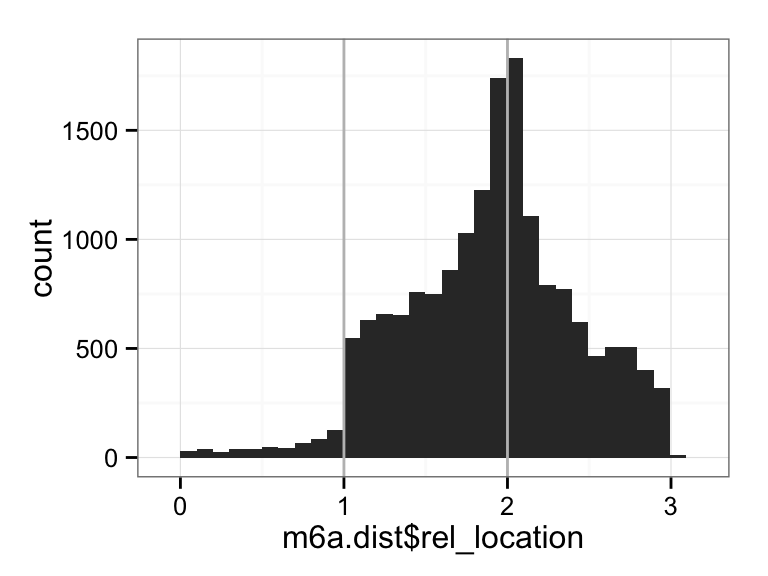

```r
library (ggplot2)
qplot(m6a.dist$rel_location, geom="histogram") + geom_vline(xintercept = 1:2, col = "grey") + theme_bw()
```

```r
summary(data.frame(m6a.dist$utr5_size, m6a.dist$cds_size, m6a.dist$utr3_size))
```

```
##  m6a.dist.utr5_size m6a.dist.cds_size m6a.dist.utr3_size
##  Min.   :    0.0    Min.   :   38     Min.   :    0
##  1st Qu.:  103.0    1st Qu.:  824     1st Qu.:  332
##  Median :  206.0    Median : 1442     Median :  768
##  Mean   :  289.8    Mean   : 1924     Mean   : 1205
##  3rd Qu.:  362.0    3rd Qu.: 2402     3rd Qu.: 1586
##  Max.   :14959.0    Max.   :26393     Max.   :17320
```

The median lengths are 206, 1442, and 768 for the 5’UTR, CDS and 3’UTR, respectively.

To account for these length differences in the metagene, we can re-scale the widths of the 5’UTR and 3’UTR relative to the CDS (which is set constant to a width of 1 unit). So first we calculate a simple scale factor (SF):

```r
utr5.SF <- median(m6a.dist$utr5_size, na.rm = T)/median(m6a.dist$cds_size, na.rm = T)
utr3.SF <- median(m6a.dist$utr3_size, na.rm = T)/median(m6a.dist$cds_size, na.rm = T)
```

The SF for the 5’UTR is 0.14 and for the 3’UTR is 0.53. Next, the following code rescales these regions accordingly:

```r
# assign the regions to new dataframes
utr5.m6a.dist <- m6a.dist[m6a.dist$rel_location < 1, ]
cds.m6a.dist <- m6a.dist [m6a.dist$rel_location < 2 & m6a.dist$rel_location >= 1, ]
utr3.m6a.dist <- m6a.dist[m6a.dist$rel_location >= 2, ]

# rescale 5'UTR and 3'UTR
library("scales")
utr5.m6a.dist$rel_location <- rescale(utr5.m6a.dist$rel_location, to = c(1-utr5.SF, 1), from = c(0,1))
utr3.m6a.dist$rel_location <- rescale(utr3.m6a.dist$rel_location, to = c(2, 2+utr3.SF), from = c(2,3))
```

Finally, plot the metagene with the rescaled UTRs

```r
# Combine and plot
## Histogram
m6a.metagene.coord <- c(utr5.m6a.dist$rel_location, cds.m6a.dist$rel_location, utr3.m6a.dist$rel_location)
p <- qplot(m6a.metagene.coord, geom="histogram") + geom_vline(xintercept = 1:2, col = "grey") + theme_bw()
```

[output not shown]

### Alternate representations of the metagene

#### A frequency polygon

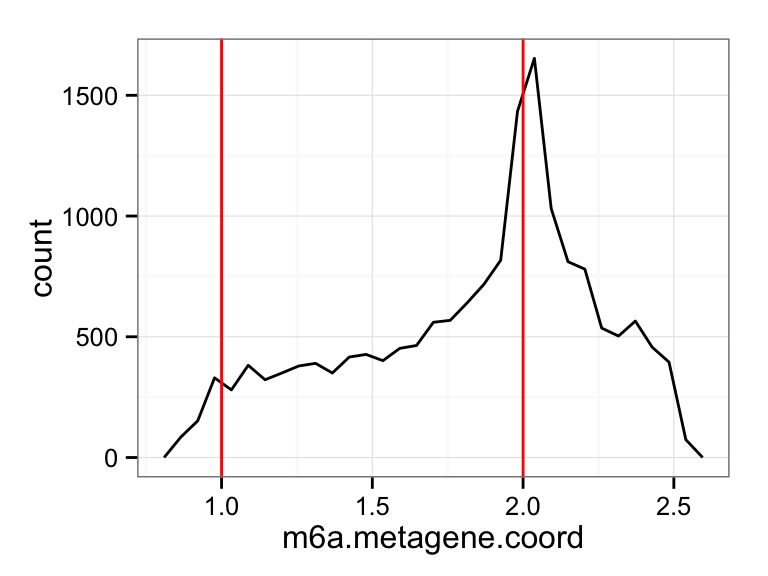

```r
qplot(m6a.metagene.coord, geom="freqpoly") + geom_vline(xintercept = 1:2, col = "red") + theme_bw()
```

#### A smooth density plot

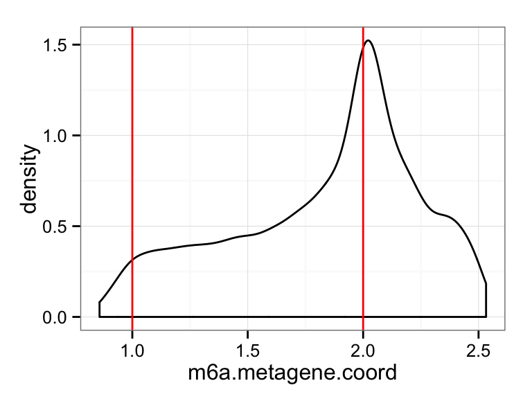

```r
qplot(m6a.metagene.coord, geom="density") + geom_vline(xintercept = 1:2, col = "red") + theme_bw()
```

### Comparing multiple metagene plots

It is often desireable to compare two or more metagene plots. These plots can represent different experimental conditions (e.g. control vs treatment) or even different groups within the same dataset (e.g. highly vs lowly expressed genes). Below we demonstrate a comparsion of the metagene for m6A to that of pseudouridine.

#### Read in pseudouridine metagene coordinates file

Note: The pseudoU metagene coordinates data was derived from the input file “pseudo.dist.measures.txt” as above for the m6A dataset. It is provided here as a file to load directly for convenience. Otherwise, you can generate it as well by repeating the steps of this tutorial for the pseudouridine dataset.

```r
# Read in metagene coordinates
pseudoU.metagene.coord <- t(read.delim ("pseudoU.meta.coord.txt", header = T))
```

#### Draw combined plots of m6A and pseudouridine metagene

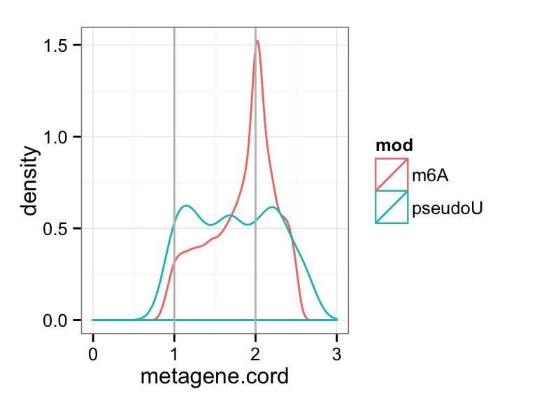

```r
metagene.cord <- c(m6a.metagene.coord, pseudoU.metagene.coord)
mod <- c(rep("m6A", length(m6a.metagene.coord)),
         rep("pseudoU", length(pseudoU.metagene.coord)))
df <- data.frame(metagene.cord, mod)

ggplot(df) + geom_density(aes(x = metagene.cord, colour = mod)) + xlim(0, 3) +
  theme_bw() + geom_vline(xintercept = 1:2, col = "grey")
```

As you can see, the pseudouridine metagene trace does not contain the prominent stop codon proximal peak seen in the m6A metagene, but is instead somewhat more uniform in the CDS and 3’UTR.

### Mapping the absolute distance of sites from fixed features

An alternative to the metagene plot is a feature distance plot which shows the absolute distance of sites from a given transcriptomic feature (e.g. stop codon, transcription start site, etc). As discussed earlier, columns 6-11 of the dataset contains the absolute distance data.

```r
head(m6a.dist[,6:11])
```

```
##       utr5_st utr5_end cds_st cds_end utr3_st utr3_end
## 4713     1057      927    926    -615    -616     -645
## 4712     1191     1026   1025    -615    -616     -648
## 13159     448      356    355    -841    -842    -1017
## 13154     190      104    103   -1051   -1052    -2239
## 13157     442      356    355    -799    -800    -1987
## 13160    2270     2184   2183    1029    1028     -159
```

For example, we can view the distribution of sites within 500 nucleotides of the stop codon:

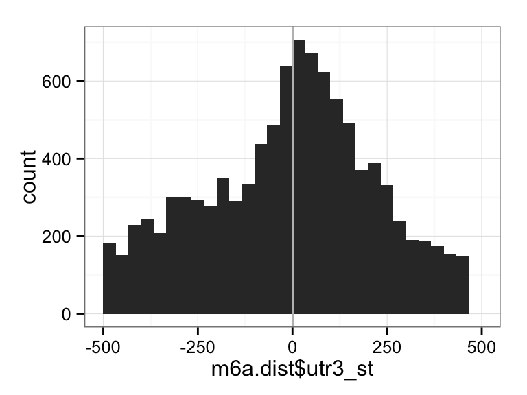

```r
qplot(m6a.dist$utr3_st, geom="histogram") + xlim (-500,500) + geom_vline(xintercept = 1:2, col = "grey") + theme_bw()
```

## Final remarks

R is a powerful language and there are many customizations that can be made to all the plots shown above. This tutorial was meant to serve as a starting point for creating metagenes and exploring the underlying data using **MetaPlotR**.